# Lab02_ZhouPeng.Rmd

Yongyi(Sophie) Peng & Tianyi Zhou

## Read in the data set

```r
badDrivers <- read.csv("./data/bad-drivers.csv")
```

#### Rename the variable name

```r
names(badDrivers) <- c("State", "Number_of_driver", "Pct_speeding","Pct_alcohol", "Pct_not_distracted", "Pct_not_previous","CIP", "Losses_incurred")
print(badDrivers)
```

```
##                   State Number_of_driver Pct_speeding Pct_alcohol
## 1               Alabama             18.8           39          30
## 2                Alaska             18.1           41          25
## 3               Arizona             18.6           35          28
## 4              Arkansas             22.4           18          26
## 5            California             12.0           35          28
## 6              Colorado             13.6           37          28
## 7           Connecticut             10.8           46          36
## 8              Delaware             16.2           38          30
## 9  District of Columbia              5.9           34          27
## 10              Florida             17.9           21          29
## 11              Georgia             15.6           19          25
## 12               Hawaii             17.5           54          41
## 13                Idaho             15.3           36          29
## 14             Illinois             12.8           36          34
```

[output cut: 89 more lines]

## Exploratory data analysis

#### draftsman plot

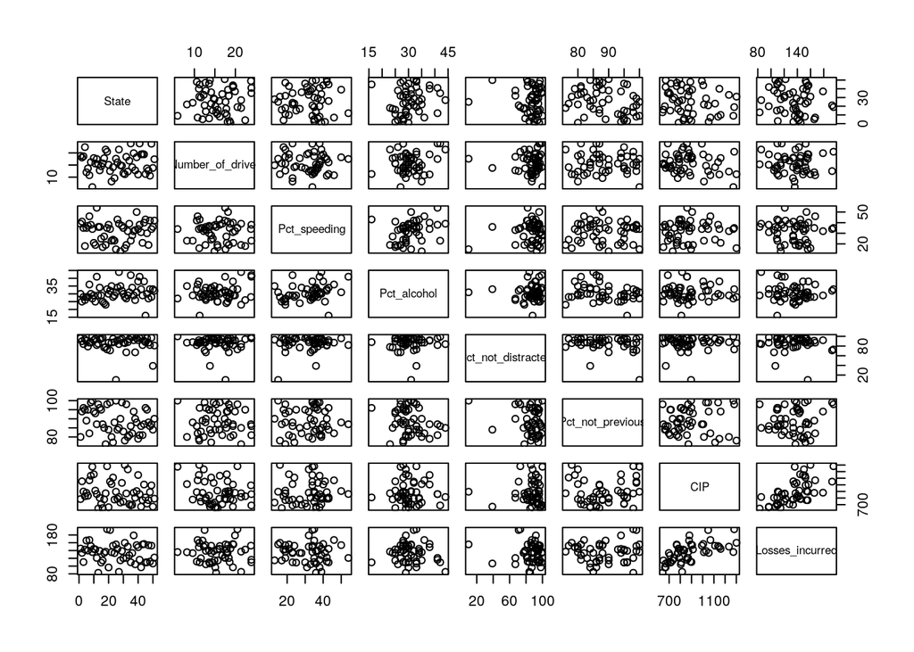

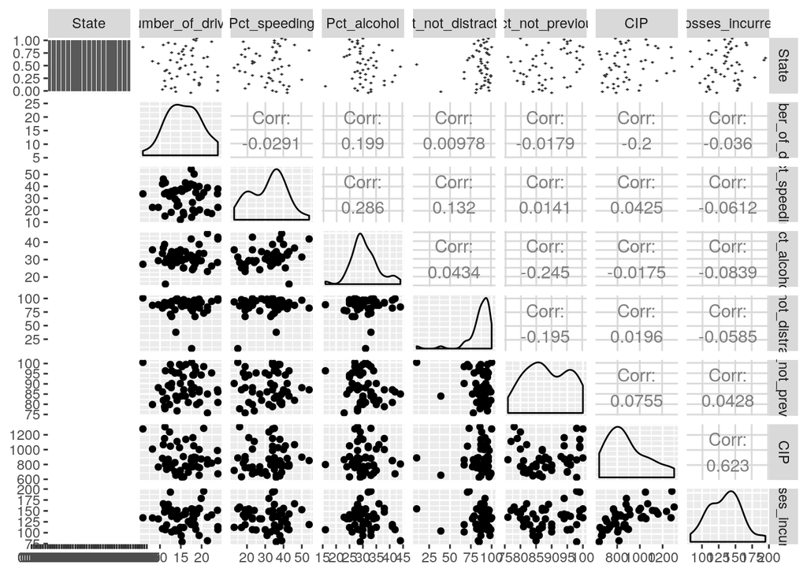

#### Question: Present a brief description of trends you see in the data, and how they may influence fitting a model.

From the draftsman plot, we observed a moderately strong positive linear relationship between Car_insurance and Losses_incurred. Since these two variables are moderately correlated, the model fit might be affected (will be more accurate) after we include the above covariation as an explanatory variable in regression.

#### Plot the estimated distribution of Percentage of Drivers Involved in Fatal Collisions who were speeding using a histogram.

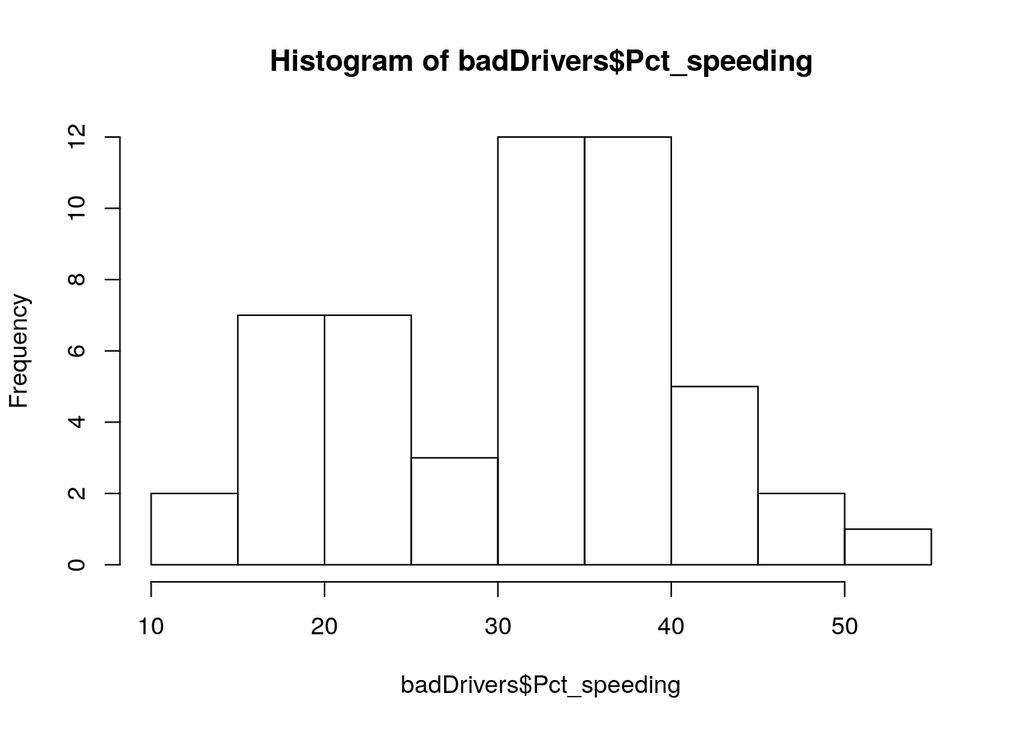

```r
hist(badDrivers$Pct_speeding)
```

## Regression analysis

The target variable for our regression models is CIP. The covariated variable we feel is most related to Car Insurance Premiums is Losses incurred by insurance companies for collisions per insured driver ($) (Losses_incurred).

#### Simple Linear Regression Model（Reg01）

CIP = Beta0 + Beta1*Losses_incurred + error

```r
Reg01<- lm(data=badDrivers, CIP~Losses_incurred)
summary(Reg01)
```

```
##
## Call:
## lm(formula = CIP ~ Losses_incurred, data = badDrivers)
##
## Residuals:
##     Min      1Q  Median      3Q     Max
## -213.33  -96.75  -40.11  112.24  379.97
##
## Coefficients:
##                 Estimate Std. Error t value Pr(>|t|)
## (Intercept)     285.3251   109.6689   2.602   0.0122 *
## Losses_incurred   4.4733     0.8021   5.577 1.04e-06 ***
## ---
## Signif. codes:  0 '***' 0.001 '**' 0.01 '*' 0.05 '.' 0.1 ' ' 1
##
## Residual standard error: 140.9 on 49 degrees of freedom
## Multiple R-squared:  0.3883, Adjusted R-squared:  0.3758
## F-statistic:  31.1 on 1 and 49 DF,  p-value: 1.043e-06
```

The predicted equation for CIP is CIP = 285.3251 + 4.4733 * Losses_incurred. This can also be written as the predicted CIP = y_hat = 285.3251 + 4.4733 * X

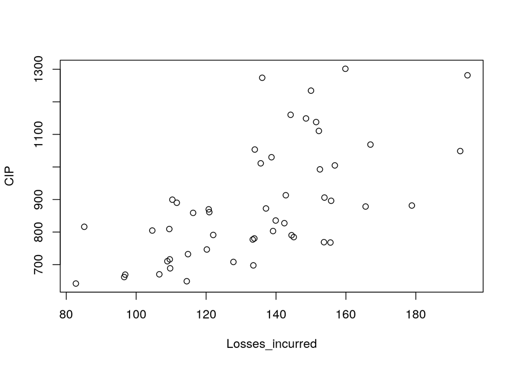

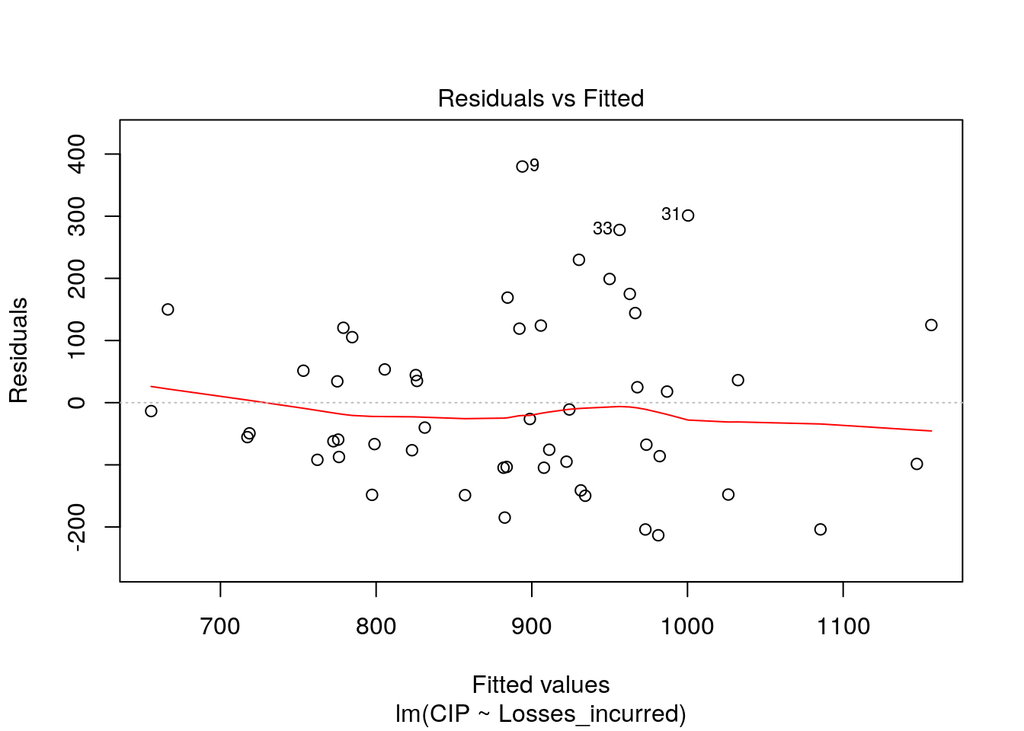

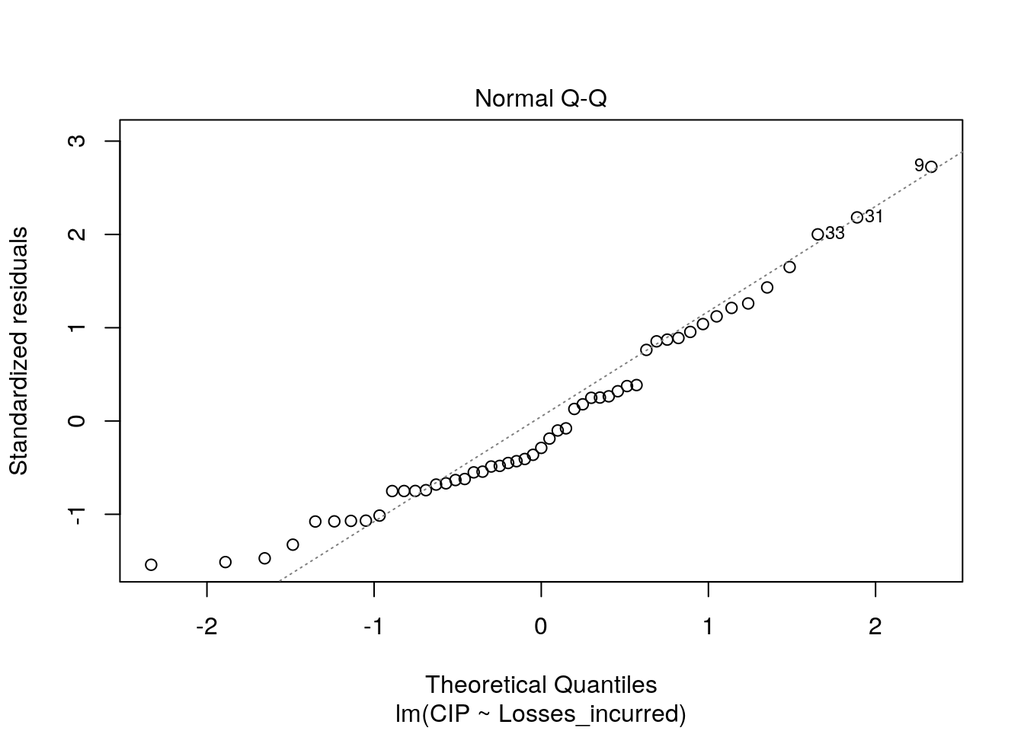

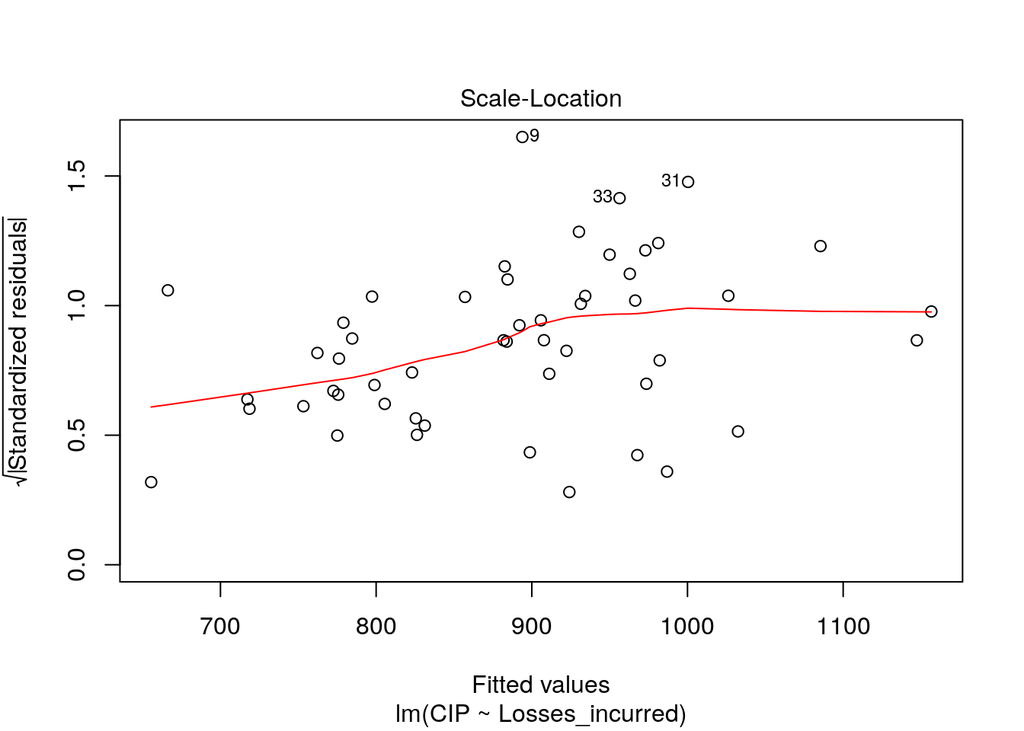

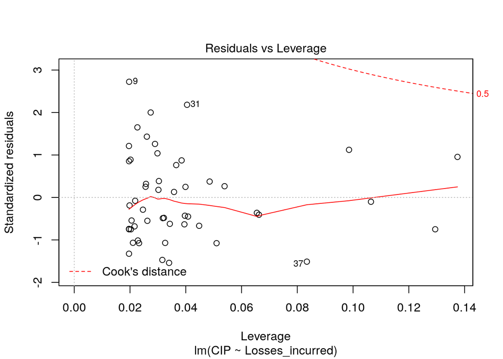

The QQ plot of the simple linear regression model is not bad.

#### Multiple Linear Regression Model（Reg02)

```r
Reg02<- lm(data=badDrivers, CIP~Losses_incurred+Number_of_driver)
summary(Reg02)
```

```
##
## Call:
## lm(formula = CIP ~ Losses_incurred + Number_of_driver, data = badDrivers)
##
## Residuals:
##     Min      1Q  Median      3Q     Max
## -226.86 -108.94  -23.36  101.01  304.11
##
## Coefficients:
##                  Estimate Std. Error t value Pr(>|t|)
## (Intercept)      412.7244   133.7256   3.086  0.00336 **
## Losses_incurred    4.4274     0.7898   5.606 9.98e-07 ***
## Number_of_driver  -7.6774     4.7589  -1.613  0.11324
## ---
## Signif. codes:  0 '***' 0.001 '**' 0.01 '*' 0.05 '.' 0.1 ' ' 1
##
## Residual standard error: 138.6 on 48 degrees of freedom
## Multiple R-squared:  0.4197, Adjusted R-squared:  0.3956
## F-statistic: 17.36 on 2 and 48 DF,  p-value: 2.123e-06
```

The predicted equation for CIP is CIP = 412.7244 + 4.4274 * Losses_incurred + (-7.6774) * Number_of_driver. This can also be written as the predicted CIP = y_hat = 412.7244 + 4.4274 * X1 + (-7.6774) * X2.

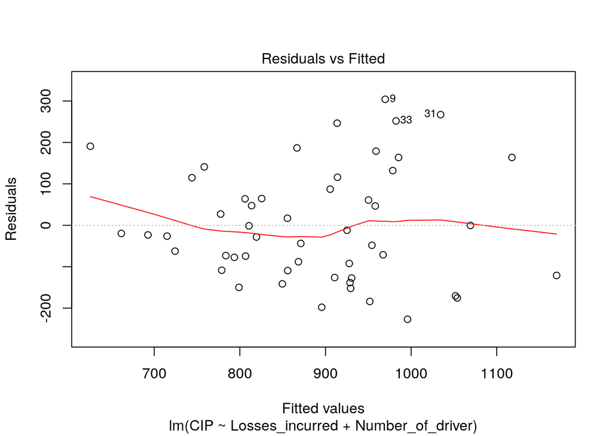

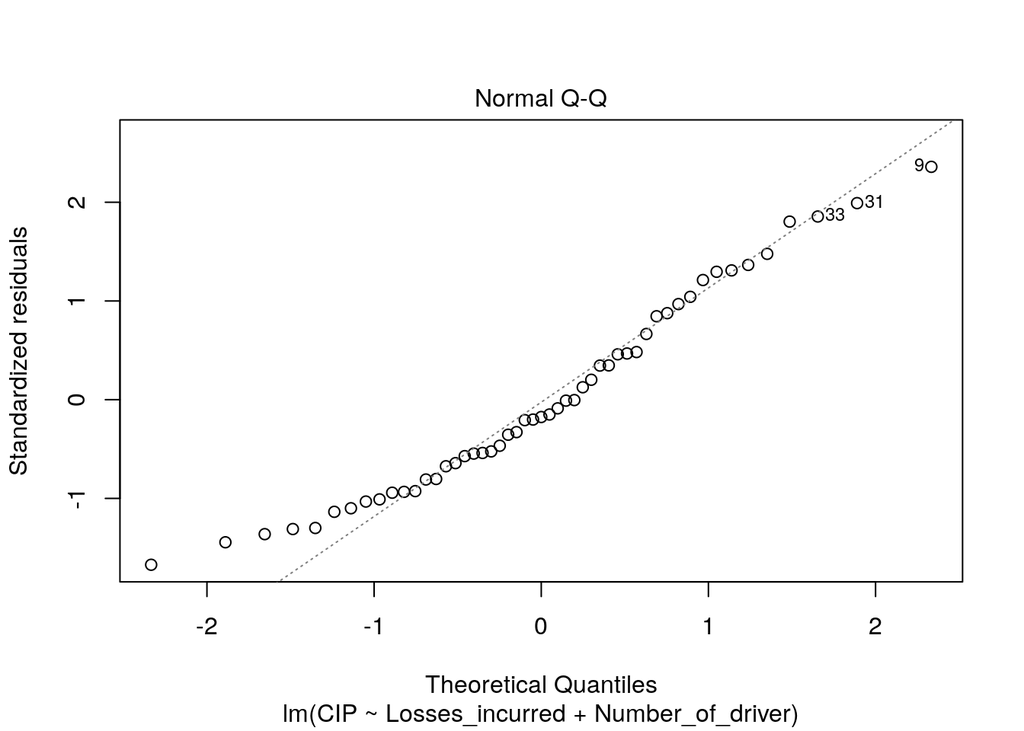

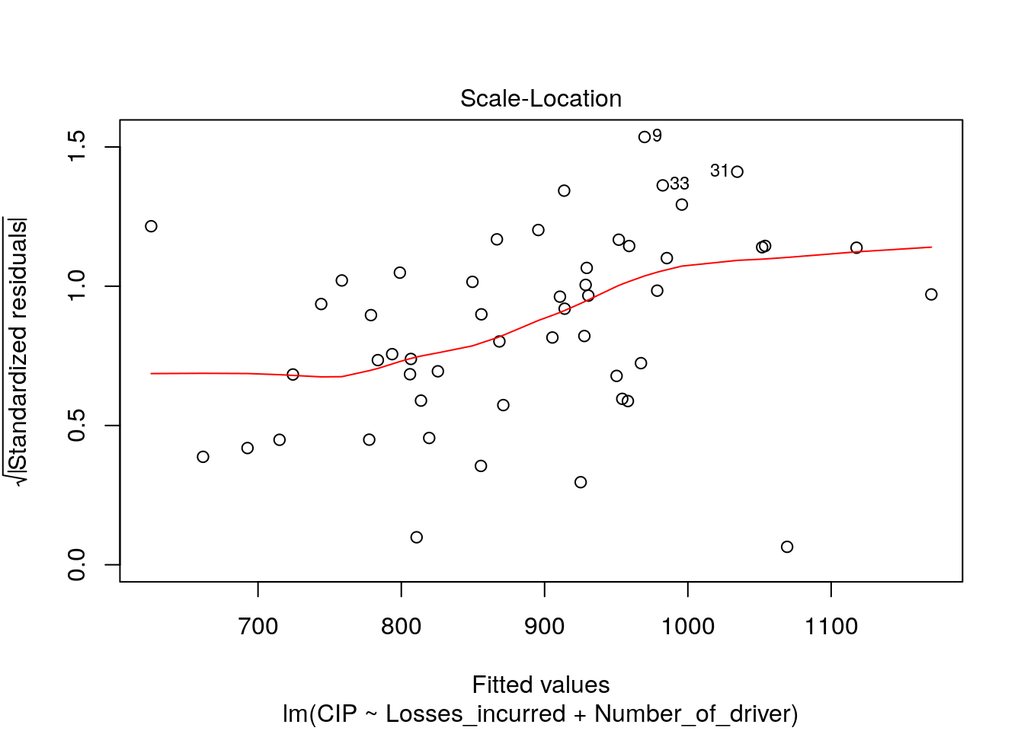

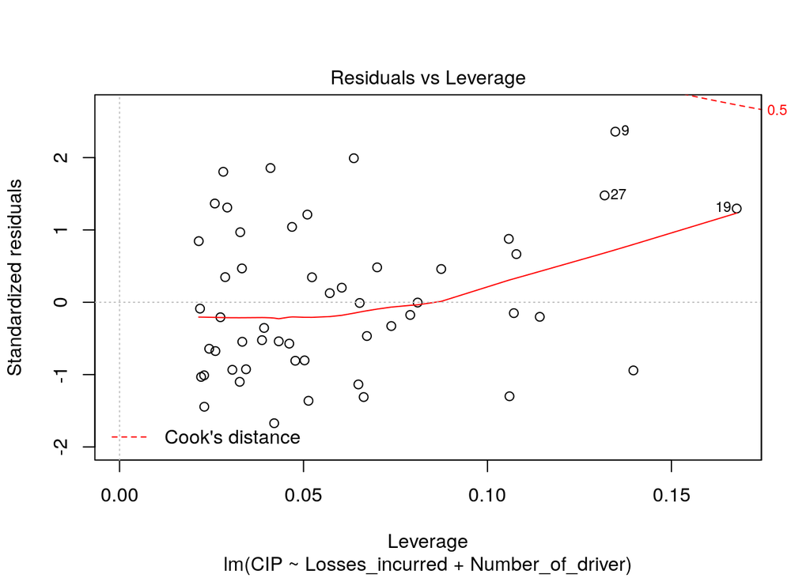

The QQ plot of multiple linear regression model seems ok.

#### Polynomial Regression Model（Reg03)

```r
Reg03<-lm(CIP~Losses_incurred+I(Losses_incurred^2), data = badDrivers)
summary(Reg03)
```

```
##
## Call:
## lm(formula = CIP ~ Losses_incurred + I(Losses_incurred^2), data = badDrivers)
##
## Residuals:
##     Min      1Q  Median      3Q     Max
## -214.29  -94.03  -41.70  111.06  377.56
##
## Coefficients:
##                        Estimate Std. Error t value Pr(>|t|)
## (Intercept)          214.040186 449.591008   0.476    0.636
## Losses_incurred        5.553480   6.651950   0.835    0.408
## I(Losses_incurred^2)  -0.003958   0.024193  -0.164    0.871
##
## Residual standard error: 142.3 on 48 degrees of freedom
## Multiple R-squared:  0.3886, Adjusted R-squared:  0.3631
## F-statistic: 15.26 on 2 and 48 DF,  p-value: 7.44e-06
```

The predicted equation for CIP is CIP = 214.040186 + 5.553480 * Losses_incurred + (-0.003958) * Losses_incurred^2. This can also be written as the predicted CIP = y_hat = 214.040186 + 5.553480 * X + (-0.003958) * X^2.

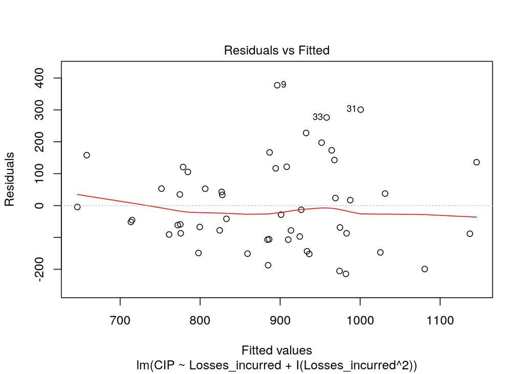

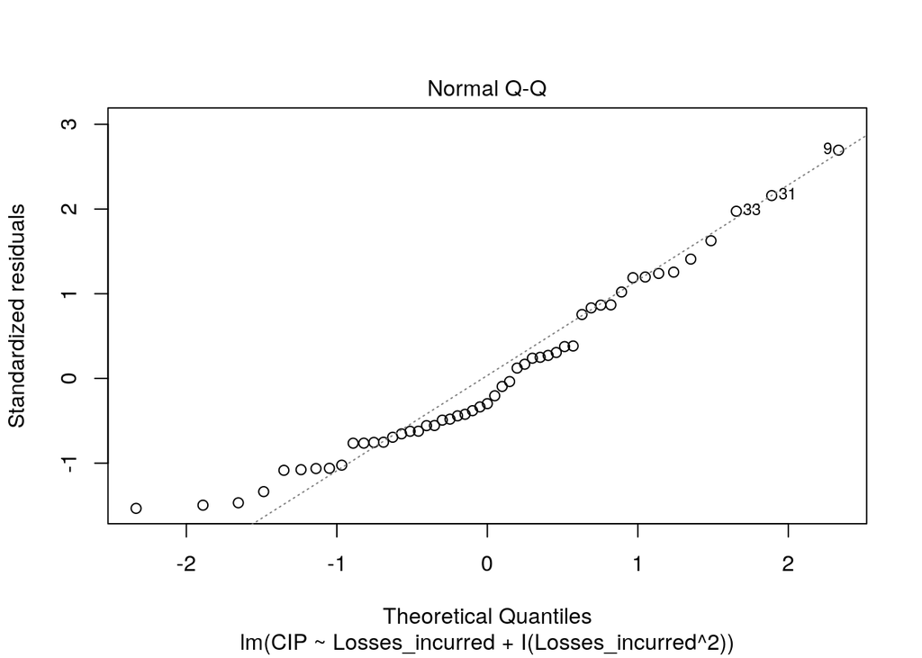

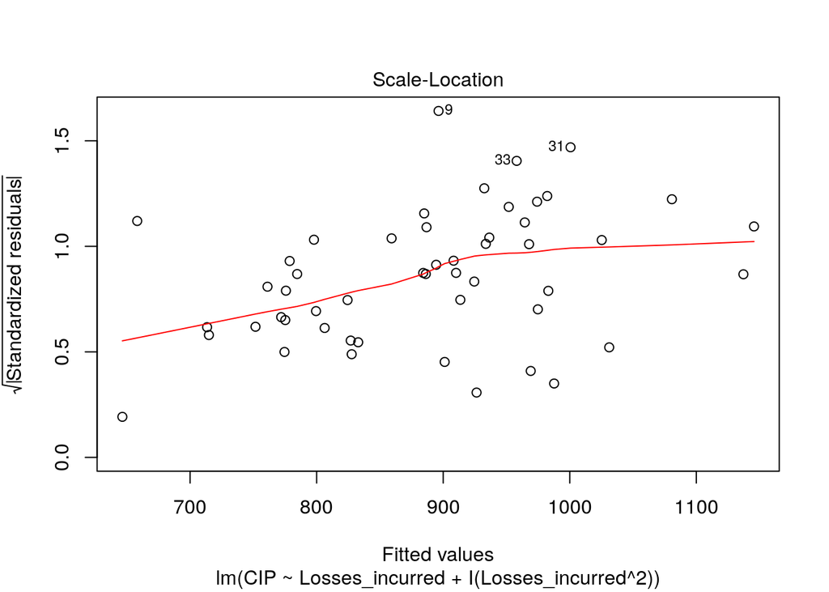

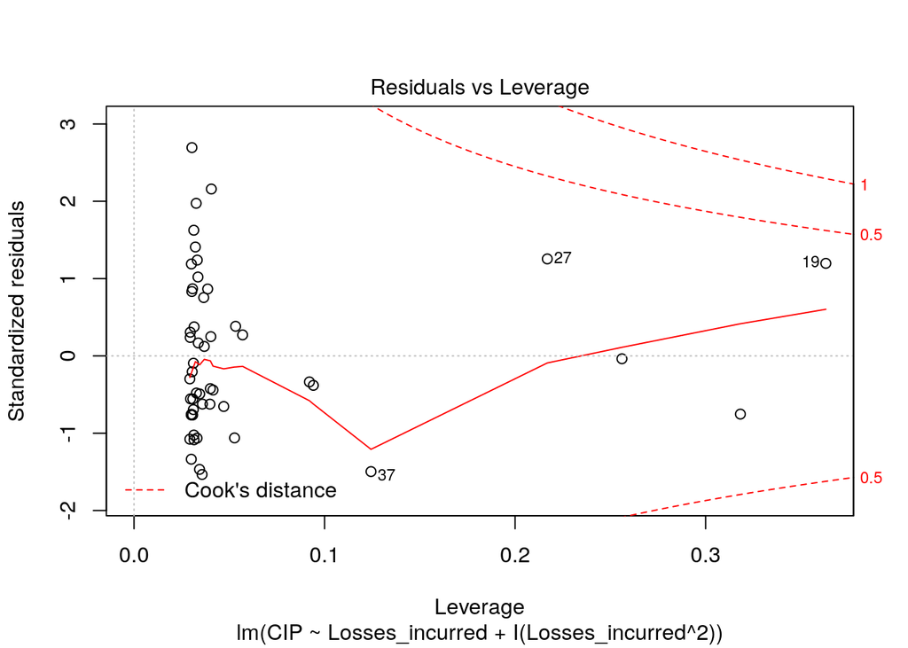

#### Choice of Model and its description

We pick Multiple Linear Regression Model（Reg02), because it has the highest Adjusted R-squared.

The predicted equation for CIP is CIP = 412.7244 + 4.4274 * Losses_incurred + (-7.6774) * Number_of_driver.  
This can also be written as the predicted CIP = y_hat = 412.7244 + 4.4274 * X1 + (-7.6774) * X2.

Number_of_driver does not significantly contribute to predicting CIP. (p-value = 0.11324)  
Losses_incurred significantly contribute to predicting CIP. (p-value = 9.98e-07)

Holding everything else constant, one unit increase in Number_of_driver is related to 7.6774 unit decrease in CIP in a similar population.  
Holding everything else constant, one unit increase in Losses_incurred is related to 4.4274 unit increase in CIP in a similar population.  
With Number_of_driver = Losses_incurred = 0, CIP = 412.7244 in a similar population.

The Adjusted R-squared value of multiple linear regression is higher than the multiple R-squared value of simple linear regression model.

## Hold-out

Select and remove 10 states from the dataset. Store these 10 states in a dataset called holdOut.

Store the remaining 41 states in a dataset called training

```r
x <- badDrivers$State

newStates <- sample(x, 10, replace = FALSE, prob = NULL)
holdOut <- badDrivers[newStates,]
training <- badDrivers[-c(newStates),]

print(holdOut)
```

```
##            State Number_of_driver Pct_speeding Pct_alcohol
## 19     Louisiana             20.5           35          33
## 40  Rhode Island             11.1           34          38
## 7    Connecticut             10.8           46          36
## 25   Mississippi             17.6           15          31
## 8       Delaware             16.2           38          30
## 49 West Virginia             23.8           34          28
## 36          Ohio             14.1           28          34
## 35  North Dakota             23.9           23          42
## 27       Montana             21.4           39          44
## 38        Oregon             12.8           33          26
##    Pct_not_distracted Pct_not_previous     CIP Losses_incurred
## 19                 73               98 1281.55          194.78
## 40                 92               79 1148.99          148.58
## 7                  87               82 1068.73          167.02
## 25                 10              100  896.07          155.77
## 8                  87               99 1137.87          151.48
## 49                 97               87  992.61          152.56
## 36                 99               82  697.73          133.52
## 35                 99               86  688.75          109.72
## 27                 84               85  816.21           85.15
## 38                 67               90  804.71          104.61
```

```r
print(training)
```

```
##                   State Number_of_driver Pct_speeding Pct_alcohol
## 1               Alabama             18.8           39          30
## 2                Alaska             18.1           41          25
## 3               Arizona             18.6           35          28
## 4              Arkansas             22.4           18          26
## 5            California             12.0           35          28
## 6              Colorado             13.6           37          28
## 9  District of Columbia              5.9           34          27
## 10              Florida             17.9           21          29
## 11              Georgia             15.6           19          25
## 12               Hawaii             17.5           54          41
## 13                Idaho             15.3           36          29
## 14             Illinois             12.8           36          34
## 15              Indiana             14.5           25          29
## 16                 Iowa             15.7           17          25
```

[output cut: 69 more lines]

```r
# Simple Linear Regression (REG01)
Reg01_train<- lm(data=training, CIP~Losses_incurred)
summary(Reg01_train)
```

```
##
## Call:
## lm(formula = CIP ~ Losses_incurred, data = training)
##
## Residuals:
##     Min      1Q  Median      3Q     Max
## -195.86  -92.79  -51.81   57.57  390.81
##
## Coefficients:
##                 Estimate Std. Error t value Pr(>|t|)
## (Intercept)     320.6827   134.1728   2.390  0.02177 *
## Losses_incurred   4.1338     0.9941   4.158  0.00017 ***
## ---
## Signif. codes:  0 '***' 0.001 '**' 0.01 '*' 0.05 '.' 0.1 ' ' 1
##
## Residual standard error: 143.6 on 39 degrees of freedom
## Multiple R-squared:  0.3072, Adjusted R-squared:  0.2894
## F-statistic: 17.29 on 1 and 39 DF,  p-value: 0.0001701
```

```r
# Multiple Linear Regression (REG02)
Reg02_train<- lm(data=training, CIP~Losses_incurred+Number_of_driver)
summary(Reg02_train)
```

```
##
## Call:
## lm(formula = CIP ~ Losses_incurred + Number_of_driver, data = training)
##
## Residuals:
##     Min      1Q  Median      3Q     Max
## -216.51 -109.97  -19.81   79.92  286.42
##
## Coefficients:
##                  Estimate Std. Error t value Pr(>|t|)
## (Intercept)      494.2392   157.8224   3.132 0.003339 **
## Losses_incurred    4.1003     0.9612   4.266 0.000127 ***
## Number_of_driver -10.9515     5.6728  -1.931 0.061027 .
## ---
## Signif. codes:  0 '***' 0.001 '**' 0.01 '*' 0.05 '.' 0.1 ' ' 1
##
## Residual standard error: 138.8 on 38 degrees of freedom
## Multiple R-squared:  0.3691, Adjusted R-squared:  0.3359
## F-statistic: 11.11 on 2 and 38 DF,  p-value: 0.0001584
```

```r
# Polynomial Regression (REG03)
Reg03_train<-lm(CIP~Losses_incurred+I(Losses_incurred^2), data = training)
summary(Reg03_train)
```

```
##
## Call:
## lm(formula = CIP ~ Losses_incurred + I(Losses_incurred^2), data = training)
##
## Residuals:
##     Min      1Q  Median      3Q     Max
## -199.99 -111.14  -35.08   67.62  370.66
##
## Coefficients:
##                        Estimate Std. Error t value Pr(>|t|)
## (Intercept)          -378.07507  568.23357  -0.665    0.510
## Losses_incurred        14.75686    8.45599   1.745    0.089 .
## I(Losses_incurred^2)   -0.03924    0.03102  -1.265    0.214
## ---
## Signif. codes:  0 '***' 0.001 '**' 0.01 '*' 0.05 '.' 0.1 ' ' 1
##
## Residual standard error: 142.5 on 38 degrees of freedom
## Multiple R-squared:  0.3352, Adjusted R-squared:  0.3002
## F-statistic: 9.579 on 2 and 38 DF,  p-value: 0.000428
```

Compute the mean-squared error (MSE) on holdOut

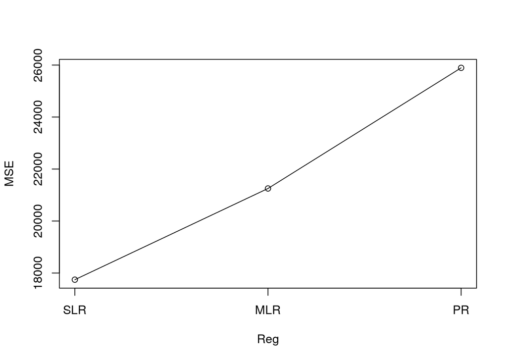

```r
MSE = function(Reg,holdOut){
  N = nrow(holdOut)
  return( sum((predict(Reg,holdOut)-holdOut$CIP)^2/N))
}


fromString2Model = function(string){
  return(eval(parse(text=string)))
}

i <-1

MSEs <- rep(0,3)
for (Reg in c("Reg01_train","Reg02_train","Reg03_train")){
  MSEs[i] <- MSE(fromString2Model(Reg), holdOut)
  i=i+1
}


plot(MSEs, xlab="Reg", ylab="MSE", xaxt="n")

lines(MSEs)

axis(1, at = c(1,2,3)
     , labels = c("SLR", "MLR","PR"))
```

```r
print(MSEs)
```

```
## [1] 17744.98 21252.52 25892.60
```

## Cross-validation

```r
a <- badDrivers$State

newStates1 <- sample(a, 10, replace = FALSE, prob = NULL)
holdOut1 <- badDrivers[newStates1,]
training1 <- badDrivers[-c(newStates1),]

b <- training1$State

newStates2 <- sample(b, 10, replace = FALSE, prob = NULL)
holdOut2 <- training1[newStates2,]
training2 <- training1[-c(newStates2),]

c <- training2$State

newStates3 <- sample(c, 10, replace = FALSE, prob = NULL)
holdOut3 <- training2[newStates3,]
training3 <- training2[-c(newStates3),]

d <- training3$State

newStates4 <- sample(d, 10, replace = FALSE, prob = NULL)
holdOut4 <- training3[newStates4,]
holdOut5 <- training3[-c(newStates4),]

print(holdOut1)
```

```
##       State Number_of_driver Pct_speeding Pct_alcohol Pct_not_distracted
## 28 Nebraska             14.9           13          35                 93
## 15  Indiana             14.5           25          29                 95
## 14 Illinois             12.8           36          34                 94
## 16     Iowa             15.7           17          25                 97
## 29   Nevada             14.7           37          32                 95
## 38   Oregon             12.8           33          26                 67
## 33 New York             12.3           32          29                 88
## 37 Oklahoma             19.9           32          29                 92
## 46  Vermont             13.6           30          30                 96
## 17   Kansas             17.8           27          24                 77
##    Pct_not_previous     CIP Losses_incurred
## 28               90  732.28          114.82
## 15               95  710.46          108.92
## 14               96  803.11          139.15
## 16               87  649.06          114.47
## 29               99 1029.87          138.71
## 38               90  804.71          104.61
## 33               80 1234.31          150.01
## 37               94  881.51          178.86
## 46               95  716.20          109.61
## 17               85  780.45          133.80
```

```r
print(holdOut2)
```

```
##                     State Number_of_driver Pct_speeding Pct_alcohol
## NA                   <NA>               NA           NA          NA
## NA.1                 <NA>               NA           NA          NA
## 11                Georgia             15.6           19          25
## 49          West Virginia             23.8           34          28
## 44                  Texas             19.4           40          38
## 41         South Carolina             23.9           38          41
## 25            Mississippi             17.6           15          31
## NA.2                 <NA>               NA           NA          NA
## 9    District of Columbia              5.9           34          27
## 50              Wisconsin             13.8           36          33
##      Pct_not_distracted Pct_not_previous     CIP Losses_incurred
## NA                   NA               NA      NA              NA
## NA.1                 NA               NA      NA              NA
## 11                   95               93  913.15          142.80
## 49                   97               87  992.61          152.56
## 44                   91               87 1004.75          156.83
## 41                   96               81  858.97          116.29
## 25                   10              100  896.07          155.77
## NA.2                 NA               NA      NA              NA
## 9                   100              100 1273.89          136.05
## 50                   39               84  670.31          106.62
```

```r
print(holdOut3)
```

```
##              State Number_of_driver Pct_speeding Pct_alcohol
## 1          Alabama             18.8           39          30
## 26        Missouri             16.1           43          34
## NA            <NA>               NA           NA          NA
## 51         Wyoming             17.4           42          32
## 36            Ohio             14.1           28          34
## 30   New Hampshire             11.6           35          30
## 18        Kentucky             21.4           19          23
## NA.1          <NA>               NA           NA          NA
## NA.2          <NA>               NA           NA          NA
## 47        Virginia             12.7           19          27
##      Pct_not_distracted Pct_not_previous    CIP Losses_incurred
## 1                    96               80 784.55          145.08
## 26                   92               84 790.32          144.45
## NA                   NA               NA     NA              NA
## 51                   81               90 791.14          122.04
## 36                   99               82 697.73          133.52
## 30                   87               83 746.54          120.21
## 18                   78               76 872.51          137.13
## NA.1                 NA               NA     NA              NA
## NA.2                 NA               NA     NA              NA
## 47                   87               88 768.95          153.72
```

```r
print(holdOut4)
```

```
##             State Number_of_driver Pct_speeding Pct_alcohol
## 4        Arkansas             22.4           18          26
## NA           <NA>               NA           NA          NA
## 5      California             12.0           35          28
## 39   Pennsylvania             18.2           50          31
## 48     Washington             10.6           42          33
## NA.1         <NA>               NA           NA          NA
## 13          Idaho             15.3           36          29
## 20          Maine             15.1           38          30
## NA.2         <NA>               NA           NA          NA
## NA.3         <NA>               NA           NA          NA
##      Pct_not_distracted Pct_not_previous    CIP Losses_incurred
## 4                    94               95 827.34          142.39
## NA                   NA               NA     NA              NA
## 5                    91               89 878.41          165.63
## 39                   96               88 905.99          153.86
## 48                   82               86 890.03          111.62
## NA.1                 NA               NA     NA              NA
## 13                   85               98 641.96           82.75
## 20                   87               84 661.88           96.57
## NA.2                 NA               NA     NA              NA
## NA.3                 NA               NA     NA              NA
```

```r
print(holdOut5)
```

```
##             State Number_of_driver Pct_speeding Pct_alcohol
## 2          Alaska             18.1           41          25
## 3         Arizona             18.6           35          28
## 6        Colorado             13.6           37          28
## 7     Connecticut             10.8           46          36
## 8        Delaware             16.2           38          30
## 10        Florida             17.9           21          29
## 12         Hawaii             17.5           54          41
## 19      Louisiana             20.5           35          33
## 21       Maryland             12.5           34          32
## 22  Massachusetts              8.2           23          35
## 23       Michigan             14.1           24          28
## 24      Minnesota              9.6           23          29
## 27        Montana             21.4           39          44
## 31     New Jersey             11.2           16          28
```

[output cut: 29 more lines]

```r
crossValResults = data.frame(3:5)
```

```r
# Simple Linear Regression (REG01-1)
Reg01_train1<- lm(data=holdOut1, CIP~Losses_incurred)
summary(Reg01_train1)
```

```
##
## Call:
## lm(formula = CIP ~ Losses_incurred, data = holdOut1)
##
## Residuals:
##     Min      1Q  Median      3Q     Max
## -170.90  -74.25  -36.11   51.57  308.92
##
## Coefficients:
##                 Estimate Std. Error t value Pr(>|t|)
## (Intercept)      264.953    282.977   0.936   0.3765
## Losses_incurred    4.403      2.157   2.041   0.0755 .
## ---
## Signif. codes:  0 '***' 0.001 '**' 0.01 '*' 0.05 '.' 0.1 ' ' 1
##
## Residual standard error: 151.5 on 8 degrees of freedom
## Multiple R-squared:  0.3424, Adjusted R-squared:  0.2602
## F-statistic: 4.166 on 1 and 8 DF,  p-value: 0.07555
```

```r
# Multiple Linear Regression (REG02-1)
Reg02_train1<- lm(data=holdOut1, CIP~Losses_incurred+Number_of_driver)
summary(Reg02_train1)
```

```
##
## Call:
## lm(formula = CIP ~ Losses_incurred + Number_of_driver, data = holdOut1)
##
## Residuals:
##      Min       1Q   Median       3Q      Max
## -208.897  -43.610    0.484   56.929  119.585
##
## Coefficients:
##                  Estimate Std. Error t value Pr(>|t|)
## (Intercept)       682.951    249.349   2.739  0.02896 *
## Losses_incurred     7.092      1.807   3.924  0.00572 **
## Number_of_driver  -51.393     17.687  -2.906  0.02280 *
## ---
## Signif. codes:  0 '***' 0.001 '**' 0.01 '*' 0.05 '.' 0.1 ' ' 1
##
## Residual standard error: 109 on 7 degrees of freedom
## Multiple R-squared:  0.7019, Adjusted R-squared:  0.6168
## F-statistic: 8.243 on 2 and 7 DF,  p-value: 0.01446
```

```r
# Polynomial Regression (REG03-1)
Reg03_train1<-lm(CIP~Losses_incurred+I(Losses_incurred^2), data = holdOut1)
summary(Reg03_train1)
```

```
##
## Call:
## lm(formula = CIP ~ Losses_incurred + I(Losses_incurred^2), data = holdOut1)
##
## Residuals:
##     Min      1Q  Median      3Q     Max
## -137.15 -104.69  -20.37   68.56  259.34
##
## Coefficients:
##                        Estimate Std. Error t value Pr(>|t|)
## (Intercept)          -1736.5579  1684.6697  -1.031    0.337
## Losses_incurred         34.1172    24.7635   1.378    0.211
## I(Losses_incurred^2)    -0.1069     0.0888  -1.204    0.268
##
## Residual standard error: 147.4 on 7 degrees of freedom
## Multiple R-squared:  0.4553, Adjusted R-squared:  0.2997
## F-statistic: 2.925 on 2 and 7 DF,  p-value: 0.1193
```

```r
# Simple Linear Regression (REG01-2)
Reg01_train2<- lm(data=holdOut2, CIP~Losses_incurred)
summary(Reg01_train2)
```

```
##
## Call:
## lm(formula = CIP ~ Losses_incurred, data = holdOut2)
##
## Residuals:
##      11      49      44      41      25       9      50
##  -52.11  -16.57  -23.64   13.01 -127.55  339.01 -132.14
##
## Coefficients:
##                 Estimate Std. Error t value Pr(>|t|)
## (Intercept)       322.67     500.21   0.645    0.547
## Losses_incurred     4.50       3.59   1.254    0.265
##
## Residual standard error: 174.6 on 5 degrees of freedom
##   (3 observations deleted due to missingness)
## Multiple R-squared:  0.2391, Adjusted R-squared:  0.08697
## F-statistic: 1.572 on 1 and 5 DF,  p-value: 0.2654
```

```r
# Multiple Linear Regression (REG02-2)
Reg02_train2<- lm(data=holdOut2, CIP~Losses_incurred+Number_of_driver)
summary(Reg02_train2)
```

```
##
## Call:
## lm(formula = CIP ~ Losses_incurred + Number_of_driver, data = holdOut2)
##
## Residuals:
##       11       49       44       41       25        9       50
##  -78.708   71.936   -4.125  130.561 -134.124  172.605 -158.144
##
## Coefficients:
##                  Estimate Std. Error t value Pr(>|t|)
## (Intercept)       473.848    468.059   1.012    0.369
## Losses_incurred     5.260      3.314   1.587    0.188
## Number_of_driver  -14.941     10.509  -1.422    0.228
##
## Residual standard error: 159.1 on 4 degrees of freedom
##   (3 observations deleted due to missingness)
## Multiple R-squared:  0.4946, Adjusted R-squared:  0.2418
## F-statistic: 1.957 on 2 and 4 DF,  p-value: 0.2555
```

```r
# Polynomial Regression (REG03-2)
Reg03_train2<-lm(CIP~Losses_incurred+I(Losses_incurred^2), data = holdOut2)
summary(Reg03_train2)
```

```
##
## Call:
## lm(formula = CIP ~ Losses_incurred + I(Losses_incurred^2), data = holdOut2)
##
## Residuals:
##       11       49       44       41       25        9       50
## -174.739   -1.441   79.625  -36.474  -47.749  172.949    7.830
##
## Coefficients:
##                        Estimate Std. Error t value Pr(>|t|)
## (Intercept)          -7674.4810  3727.8857  -2.059   0.1086
## Losses_incurred        127.7962    57.2401   2.233   0.0893 .
## I(Losses_incurred^2)    -0.4652     0.2157  -2.156   0.0973 .
## ---
## Signif. codes:  0 '***' 0.001 '**' 0.01 '*' 0.05 '.' 0.1 ' ' 1
##
## Residual standard error: 132.7 on 4 degrees of freedom
##   (3 observations deleted due to missingness)
## Multiple R-squared:  0.6482, Adjusted R-squared:  0.4723
## F-statistic: 3.685 on 2 and 4 DF,  p-value: 0.1238
```

```r
# Simple Linear Regression (REG01-3)
Reg01_train3<- lm(data=holdOut3, CIP~Losses_incurred)
summary(Reg01_train3)
```

```
##
## Call:
## lm(formula = CIP ~ Losses_incurred, data = holdOut3)
##
## Residuals:
##          1         26         51         36         30         18
##   0.001128   6.196382  22.143265 -79.015803 -21.221474  93.327425
##         47
## -21.430923
##
## Coefficients:
##                 Estimate Std. Error t value Pr(>|t|)
## (Intercept)      686.619    259.171   2.649   0.0455 *
## Losses_incurred    0.675      1.891   0.357   0.7357
## ---
## Signif. codes:  0 '***' 0.001 '**' 0.01 '*' 0.05 '.' 0.1 ' ' 1
##
## Residual standard error: 57.26 on 5 degrees of freedom
##   (3 observations deleted due to missingness)
## Multiple R-squared:  0.02486,    Adjusted R-squared:  -0.1702
## F-statistic: 0.1274 on 1 and 5 DF,  p-value: 0.7357
```

```r
# Multiple Linear Regression (REG02-3)
Reg02_train3<- lm(data=holdOut3, CIP~Losses_incurred+Number_of_driver)
summary(Reg02_train3)
```

```
##
## Call:
## lm(formula = CIP ~ Losses_incurred + Number_of_driver, data = holdOut3)
##
## Residuals:
##        1       26       51       36       30       18       47
## -29.7908   8.0663   0.4362 -57.5311  24.9109  29.9073  24.0012
##
## Coefficients:
##                  Estimate Std. Error t value Pr(>|t|)
## (Intercept)      547.5640   188.6909   2.902   0.0440 *
## Losses_incurred    0.3082     1.3242   0.233   0.8274
## Number_of_driver  11.8122     4.6988   2.514   0.0658 .
## ---
## Signif. codes:  0 '***' 0.001 '**' 0.01 '*' 0.05 '.' 0.1 ' ' 1
##
## Residual standard error: 39.85 on 4 degrees of freedom
##   (3 observations deleted due to missingness)
## Multiple R-squared:  0.622,  Adjusted R-squared:  0.433
## F-statistic: 3.291 on 2 and 4 DF,  p-value: 0.1429
```

```r
# Polynomial Regression (REG03-3)
Reg03_train3<-lm(CIP~Losses_incurred+I(Losses_incurred^2), data = holdOut3)
summary(Reg03_train3)
```

```
##
## Call:
## lm(formula = CIP ~ Losses_incurred + I(Losses_incurred^2), data = holdOut3)
##
## Residuals:
##       1      26      51      36      30      18      47
##  -3.918   1.321  27.136 -89.739 -11.654  82.291  -5.436
##
## Coefficients:
##                        Estimate Std. Error t value Pr(>|t|)
## (Intercept)          -869.89029 3845.97273  -0.226    0.832
## Losses_incurred        23.75703   56.91533   0.417    0.698
## I(Losses_incurred^2)   -0.08496    0.20936  -0.406    0.706
##
## Residual standard error: 62.74 on 4 degrees of freedom
##   (3 observations deleted due to missingness)
## Multiple R-squared:  0.06342,    Adjusted R-squared:  -0.4049
## F-statistic: 0.1354 on 2 and 4 DF,  p-value: 0.8772
```

```r
# Simple Linear Regression (REG01-4)
Reg01_train4<- lm(data=holdOut4, CIP~Losses_incurred)
summary(Reg01_train4)
```

```
##
## Call:
## lm(formula = CIP ~ Losses_incurred, data = holdOut4)
##
## Residuals:
##      4      5     39     48     13     20
## -22.67 -39.00  22.72 129.26 -35.08 -55.24
##
## Coefficients:
##                 Estimate Std. Error t value Pr(>|t|)
## (Intercept)      437.047    132.866   3.289   0.0302 *
## Losses_incurred    2.900      1.029   2.818   0.0479 *
## ---
## Signif. codes:  0 '***' 0.001 '**' 0.01 '*' 0.05 '.' 0.1 ' ' 1
##
## Residual standard error: 76.72 on 4 degrees of freedom
##   (4 observations deleted due to missingness)
## Multiple R-squared:  0.6651, Adjusted R-squared:  0.5813
## F-statistic: 7.942 on 1 and 4 DF,  p-value: 0.04792
```